# Clustering tipo produccion

# 8.1. Clustering tipo de produccion - precio medio - demanda

# Nota: estos resultados corresponden al apartado 2.6.6. K-means precio medio, demanda y tipo de produccion

```r
#Creamos data frame con las variables a analizar
clus9<-electricity_prices[,c("PM", "eol", "nuc", "hid", "cco", "sol", "dem")]
#Eliminamos las columnas con valor NA
clus9.na<-clus9[!is.na(clus9$hid),]
clus9.na<-clus9.na[!is.na(clus9.na$sol),]
clus_p<-clus9.na
```

```r
#Normalizamos las variables
clus_p[,c("eol")]<-(clus9.na$eol-mean(clus9.na$eol))/sd(clus9.na$eol)
clus_p[,c("nuc")]<-(clus9.na$nuc-mean(clus9.na$nuc))/sd(clus9.na$nuc)
clus_p[,c("hid")]<-(clus9.na$hid-mean(clus9.na$hid))/sd(clus9.na$hid)
clus_p[,c("cco")]<-(clus9.na$cco-mean(clus9.na$cco))/sd(clus9.na$cco)
clus_p[,c("sol")]<-(clus9.na$sol-mean(clus9.na$sol))/sd(clus9.na$sol)
clus_p[,c("PM")]<-(clus9.na$PM-mean(clus9.na$PM))/sd(clus9.na$PM)
clus_p[,c("dem")]<-(clus9.na$dem-mean(clus9.na$dem))/sd(clus9.na$dem)
```

```r
#Creamos tabla para comprobar que no quedan NAs
summary(clus_p)
```

```
       PM                eol               nuc               hid                cco               sol               dem
 Min.   :-2.89100   Min.   :-1.6670   Min.   :-3.6501   Min.   :-3.62148   Min.   :-3.7316   Min.   :-0.8742   Min.   :-2.37558
 1st Qu.:-0.49561   1st Qu.:-0.7790   1st Qu.:-0.4666   1st Qu.:-0.75150   1st Qu.:-0.5813   1st Qu.:-0.8239   1st Qu.:-0.85546
 Median : 0.06737   Median :-0.2007   Median : 0.7910   Median : 0.09751   Median : 0.2758   Median :-0.5202   Median : 0.05705
 Mean   : 0.00000   Mean   : 0.0000   Mean   : 0.0000   Mean   : 0.00000   Mean   : 0.0000   Mean   : 0.0000   Mean   : 0.00000
 3rd Qu.: 0.63164   3rd Qu.: 0.6079   3rd Qu.: 0.7910   3rd Qu.: 0.91294   3rd Qu.: 0.6570   3rd Qu.: 0.7277   3rd Qu.: 0.76279
 Max.   : 3.73670   Max.   : 3.7196   Max.   : 0.7910   Max.   : 1.76121   Max.   : 1.6193   Max.   : 2.5721   Max.   : 2.87694
```

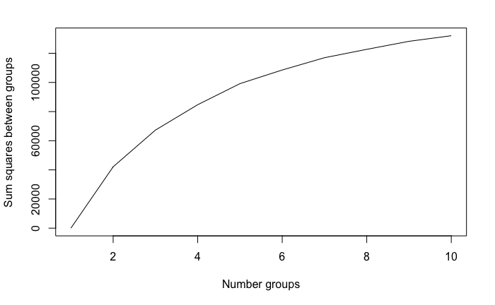

```r
#Buscamos el numero optimo de grupos maximizando la suma de cuadrados entre grupos
set.seed(345)
bss9<-kmeans(clus_p, centers=1)$betweenss
for(i in 2:10) bss9[i] <-kmeans(clus_p, centers=i)$betweenss
plot(1:10, bss9, type="l", xlab="Number groups", ylab="Sum squares between groups")
```

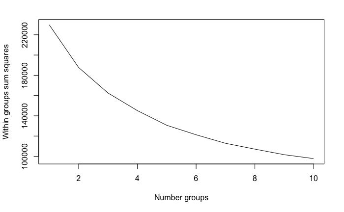

```r
#Buscamos el numero optimo de grupos minimizando la suma de cuadrados entre grupos
set.seed(345)
bss_10<-kmeans(clus_p, centers=1)$tot.withins
for(i in 2:10) bss_10[i] <-kmeans(clus_p, centers=i)$tot.withins
plot(1:10, bss_10, type="l", xlab="Number groups", ylab="Within groups sum squares")
```

```r
#Realizamos k-means con semilla 345 y k=5
set.seed(345)
clus_p_k5_1<-kmeans(clus_p, centers=5)
clus_p_k5_1$centers
```

```
          PM         eol        nuc        hid        cco        sol        dem
1  0.3394360 -0.50905514  0.1579624 -0.5860994  0.3220763  1.5540722  0.6785223
2  0.6782410  0.08777640  0.3457261  0.7582099  0.3675192 -0.3239268  0.9308884
3  0.2049775 -0.08899229 -1.4827922 -0.1674234 -0.9218337 -0.1476474 -0.3035694
4 -1.3776111  1.18790039  0.3817438  0.8959351  0.0150995 -0.3680513 -0.4455058
5  0.1248780 -0.50235433  0.4187043 -0.6610634  0.1405997 -0.5859304 -0.6605241
```

```r
aggregate(clus9.na, by=list(clus_p_k5_1$cluster), mean)
```

| Group.1 | PM | eol | nuc | hid | cco | sol | dem |
| --- | --- | --- | --- | --- | --- | --- | --- |
| 1 | 50.20853 | 3886.502 | 6608.161 | 12791.44 | 23040.91 | 4112.0250 | 31477.29 |
| 2 | 55.47436 | 5798.022 | 6759.153 | 13880.01 | 23094.11 | 931.8646 | 32629.45 |
| 3 | 48.11873 | 5231.871 | 5288.731 | 13130.46 | 21584.65 | 1230.3721 | 26993.62 |
| 4 | 23.52158 | 9321.477 | 6788.117 | 13991.53 | 22681.53 | 857.1452 | 26345.62 |
| 5 | 46.87379 | 3907.963 | 6817.839 | 12730.73 | 22828.46 | 488.1938 | 25363.97 |

Interpretacion (no se incluyen nuc hid y cco porque no presentan cambios importantes en produccion):

Observamos que los clusters 3 y 4 tienen demanda similar pero en el cluster 4 el precio es casi la mitad. Si analizamos los tipos de produccion vemos que en este caso la produccion eolica es mucho mas alta. Por otra parte, el cluster 5 tiene la demanda mas baja pero el precio no es bajo. En este caso, podemos observar que la produccion eolica es baja.

Por lo tanto, el precio parece venir marcado por la demanda y la produccion eolica (que disminuye el coste)

```r
cluster_p<-clus9.na
cluster_p$cluster<-clus_p_k5_1$cluster
table(cluster_p$cluster)
```

```
   1    2    3    4    5
6386 6070 6000 6196 8178
```

Observamos que los clusters tienen un numero similar de observaciones, siendo el cluster 5 el que mas observaciones tiene.

```r
#Realizamos el mismo analisis cambiando la semilla para contrastar los resultados.
set.seed(123)
bss_11<-kmeans(clus_p, centers=1)$tot.withins
for(i in 2:10) bss_11[i] <-kmeans(clus_p, centers=i)$tot.withins
```

```
did not converge in 10 iterations
```

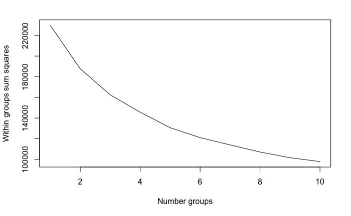

```r
plot(1:10, bss_11, type="l", xlab="Number groups", ylab="Within groups sum squares")
```

Escogemos de nuevo 5 grupos

```r
set.seed(123)
clus_p_k5_2<-kmeans(clus_p, centers=5)
clus_p_k5_2$centers
```

```
           PM        eol        nuc        hid        cco         sol         dem
1 -1.20044107  1.3194541  0.3676630  0.9181281  0.0541977 -0.33047089 -0.11498048
2  0.61687540 -0.3804955  0.2060308 -0.7594493 -1.4852415 -0.26387911 -0.05053493
3  0.55535702 -0.3485693  0.3224567 -0.1641678  0.5763122  0.92455688  0.94473531
4 -0.03445942 -0.4002518  0.3832657 -0.1067502  0.4503652 -0.59354413 -0.68482580
5  0.16982843 -0.1590179 -1.8001519 -0.1005623 -0.4952324  0.08843711 -0.25496810
```

```r
aggregate(clus9.na, by=list(clus_p_k5_2$cluster), mean)
```

| Group.1 | PM | eol | nuc | hid | cco | sol | dem |
| --- | --- | --- | --- | --- | --- | --- | --- |
| 1 | 26.27522 | 9742.815 | 6776.794 | 14009.50 | 22727.31 | 920.7830 | 27854.61 |
| 2 | 54.52059 | 4298.250 | 6646.816 | 12651.06 | 20925.07 | 1033.5480 | 28148.83 |
| 3 | 53.56445 | 4400.503 | 6740.441 | 13133.10 | 23338.55 | 3046.0183 | 32692.66 |
| 4 | 44.39732 | 4234.975 | 6789.341 | 13179.60 | 23191.10 | 475.3008 | 25253.02 |
| 5 | 47.57243 | 5007.594 | 5033.523 | 13184.61 | 22084.08 | 1630.1522 | 27215.50 |

Observamos de nuevo que el grupo 1 y 2 tienen demanda similar pero el precio del grupo 1 es mucho mas bajo. La distribucion de produccion del grupo 1 incluye casi el doble de produccion eolica que el grupo 2. La demanada mas baja se encuentra en el grupo 4, no obstante el precio es medio. Si observamos la distribucion de la produccion, ese grupo tiene muy poca produccion solar y poca produccion eolica.

Nos quedamos con la solucion con semilla 345, dado que los resultados son mas faciles de interpretar ya que los grupos son mas heterogeneos.